# Bioinfo_HW2_1

Rhodes

2015年11月26日

## Hierarchical Clustering Based on Original Data

I use the R code as followed to do the hierarchical clustering, in which the method I choose is “average”.

```r
library(RColorBrewer)
GeneMatrix <- read.delim("D:/GeneMatrix.txt")
GeneMatrix <- t(GeneMatrix)
length<-length(GeneMatrix[1,])
GeneMatrix <- as.data.frame(GeneMatrix)
#Calculate the distance
dist=dist(GeneMatrix,method="euclidean")
#Hierarchical Clustering Model
H_cluster<-hclust(dist,method="average")
model<-H_cluster
H_cluster<-cbind(GeneMatrix,Cluster=H_cluster$order)
H_cluster<-as.data.frame(H_cluster)
H_cluster<-H_cluster[order(H_cluster$Cluster),]
H_cluster<-H_cluster[,1:length]
Matrix<-data.matrix(H_cluster)
```

The hierarchical clustering leads to the heatmap as followed, I use the “heatmap” function instead of the ggplot function because of the efficiency.In R, hclust function do the hierarchical clustering automatically:

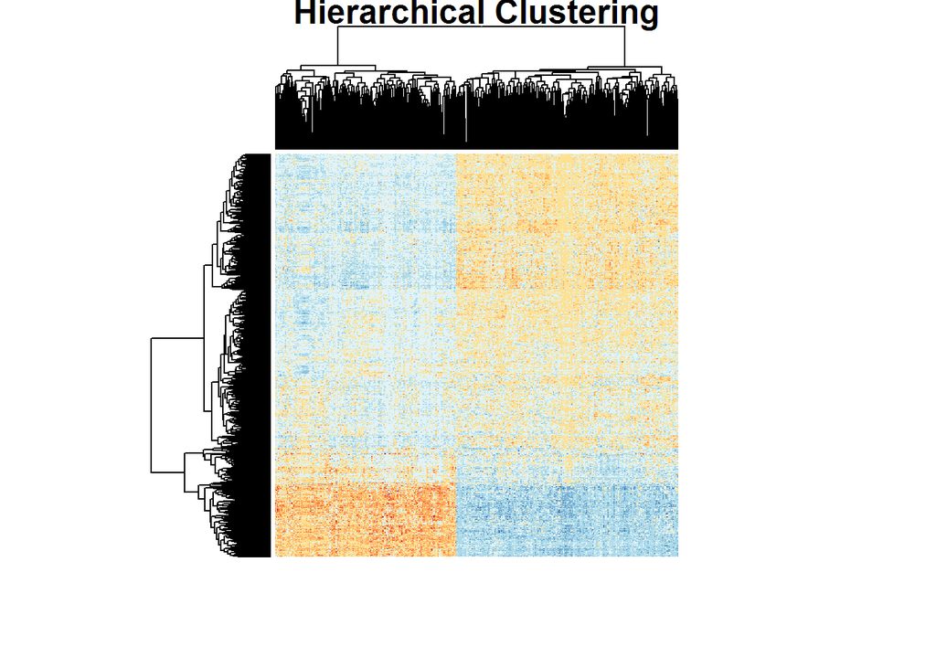

You can still see there are “horizontal stripes” in the heatmap, which implies the classification of the patients.

Now I try to use the model to do the prediction to see whether the clustering is successful or not

```
## [1] "Error Rate:"
```

```
## [1] 0.06321839
```

Then Before the PCA process, which is a method of feature extracting, I use the Boruta Package to do the feature election work. The result of the feature election can provide some reference for the number of the features I choose later. The Boruta fit a Random Forest model to the data and use the Z value as the attribution of the features during the process. The Code is as followed:(It might take a while, so please be patient)

```r
GeneMatrix <- read.delim("D:/GeneMatrix.txt")
GeneMatrix <- t(GeneMatrix)
length<-length(GeneMatrix[1,])
GeneMatrix <- as.data.frame(GeneMatrix)
clinical_data <- read.delim("D:/clinical_data.txt")
state=clinical_data[1,8]
GeneMatrix <- cbind(state,GeneMatrix)
names(GeneMatrix)[which(names(GeneMatrix[,])=="PH-4")]=c("PH4")
for(i in 1:3)
{
  clinical_data$sampleID=sub("-",".",clinical_data$sampleID)
}
for( i in 1:length(GeneMatrix$state))
{
  GeneMatrix[i,1]=clinical_data[which(clinical_data$sampleID==row.names(GeneMatrix[i,])),8]
}
library(Boruta)
select <- Boruta(state~.,data=GeneMatrix,doTrace=2)
SelectGeneMatrix=GeneMatrix[,getSelectedAttributes(select)]
select
```

```
## Boruta performed 99 iterations in 6.928167 mins.
##  74 attributes confirmed important: ACADSB, AGR2, AGR3, ANXA9,
## ATP5G2 and 69 more.
##  249 attributes confirmed unimportant: `STS-1`, ABAT, ABLIM3,
## ABTB2, ACE2 and 244 more.
##  66 tentative attributes left: AADAT, ABCC8, AFF3, AKR1CL2, ARSG
## and 61 more.
```

```r
length<-length(SelectGeneMatrix[1,])
H_cluster<-hclust(dist(SelectGeneMatrix),method="average")
newmodel<-H_cluster
H_cluster<-cbind(SelectGeneMatrix,Cluster=H_cluster$order)
H_cluster<-as.data.frame(H_cluster)
H_cluster<-H_cluster[order(H_cluster$Cluster),]
H_cluster<-H_cluster[,1:length]
Matrix<-data.matrix(H_cluster)
```

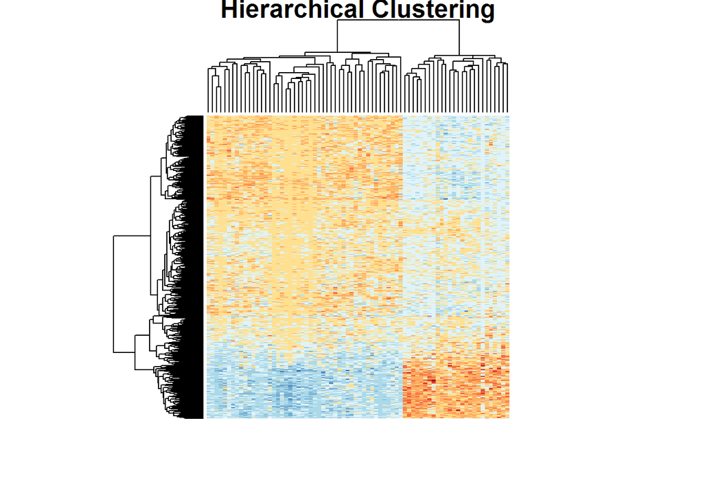

```r
predict=cutree(newmodel,k=2)
predict<-as.data.frame(predict)
count=0
for(i in 1:length(GeneMatrix[,1]))
{
  if((as.character(GeneMatrix[i,1])=="Positive" && predict[i,1]=="2") || (as.character(GeneMatrix[i,1])=="Negative" && predict[i,1]=="1"))
    count=count+1
}
```

```
## [1] "Error Rate:"
```

```
## [1] 0.06704981
```

## Hierarchical Clustering Based on Data after PCA

Finally, I use the K-L transition which is the same as PCA.

```r
library(RColorBrewer)
#读取数据
GeneMatrix <- read.delim("D:/GeneMatrix.txt")
GeneMatrix <- t(GeneMatrix)
GeneMatrix <- as.data.frame(GeneMatrix)

data=scale(GeneMatrix)

pca=princomp(data,cor=T)
```

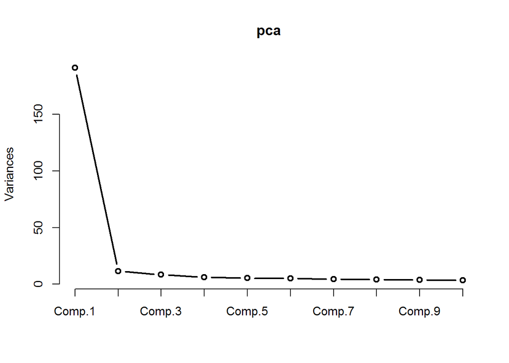

```r
cor_table=cor(data)
eigen=eigen(cor_table)
sumeigv=sum(eigen$values)
k=389
#0.90 can be modified into any another number, which impies how much information will be thrown away.
while ((sum(eigen$values[1:k])/sumeigv) >= 0.85)
{
  k = k - 1
}
k=k+1
k
```

```
## [1] 70
```

```r
vectors=pca$loadings[,1:k]
```

```r
features<-as.data.frame(0)

for(i in 1:k)
{
  for(j in 1:length(GeneMatrix[,1]))
    features[j,i]=matrix(data[j,],1,389)%*%matrix(vectors[,i],389,1)
}

newdata<-features
rownames(newdata)<-rownames(GeneMatrix)
dist=dist(newdata,method="euclidean")
model<-hclust(dist,method="average")
Matrix<-data.matrix(dist)
```

Then I can plot the heatmap

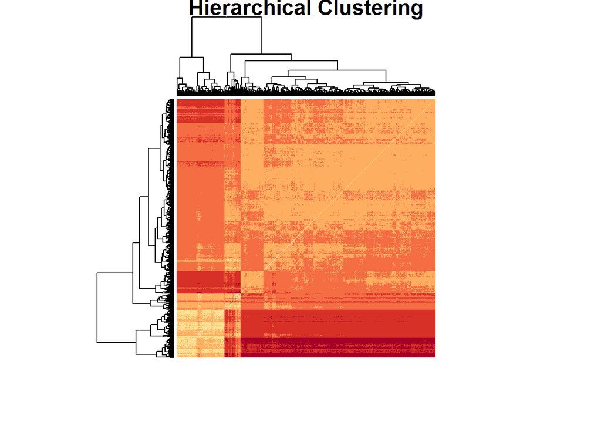

Finally, using the model to do the prediction to see the amount of information that has been lost during the PCA process.

```r
predict=cutree(model,k=2)
predict<-as.data.frame(predict)

clinical_data <- read.delim("D:/clinical_data.txt")
state=clinical_data[1,8]
GeneMatrix <- cbind(state,GeneMatrix)
names(GeneMatrix)[which(names(GeneMatrix[,])=="PH-4")]=c("PH4")
for(i in 1:3)
{
  clinical_data$sampleID=sub("-",".",clinical_data$sampleID)
}
for( i in 1:length(GeneMatrix$state))
{
  GeneMatrix[i,1]=clinical_data[which(clinical_data$sampleID==row.names(GeneMatrix[i,])),8]
}
count=0
for(i in 1:length(GeneMatrix[,1]))
{
  if((as.character(GeneMatrix[i,1])=="Positive" && predict[i,1]=="2") || (as.character(GeneMatrix[i,1])=="Negative" && predict[i,1]=="1"))
    count=count+1
}
```

```
## [1] "Error Rate:"
```

```
## [1] 0.09386973
```